# IODS-Final assignment

Ahmed Gamal Abushahba

ahmed.abushahba@helsinki.fi

12.12.2017

# **Insights on human dataset**

# Linear Regression Analysis

## *Introduction*

This part of my final assignment will focus on analysing a data set named *humanW*, it originates from the United Nations Development Programme. See [their data page](http://hdr.undp.org/en/content/human-development-index-hdi) for more information. For a nice overview see also [the calculating the human development indices pdf](http://hdr.undp.org/sites/default/files/hdr2015_technical_notes.pdf). Most of the variable names in the data have been shortened and two new variables have been computed. See the [meta file](https://raw.githubusercontent.com/TuomoNieminen/Helsinki-Open-Data-Science/master/datasets/human_meta.txt). For the modified data please check our renamed variables and [wrangled raw data](https://github.com/Abushahba/IODS-final/blob/master/data/humanW.csv), as well as [R script for data wrangling](https://github.com/Abushahba/IODS-final/blob/master/data/create_human.R).

Briefly, the data combines several indicators from most countries in the world that can be broadly classified into those related to **Health and knowledge** and others related to **Empowerment**.

## *Research Question*

Is the **Gross National Income per Capita (GNI)** as predicted with other development indices in *African nations* compared with *Non-African nations*?

## *Characteristics of the dataset*

First, we will read our working dataset, inspect its structure and dimensions.

```r
#read saved modified dataset into an object
humanW <- read.csv(file = "C:/Users/ahmed/Desktop/IODS-final-master/IODS-final/data/humanW.csv", row.names=1, header=TRUE)

#exploring structure and dimensions of dataset
str(humanW)
```

```
## 'data.frame':    155 obs. of  8 variables:
##  $ Edu2.FM  : num  1.007 0.997 0.983 0.989 0.969 ...
##  $ Labo.FM  : num  0.891 0.819 0.825 0.884 0.829 ...
##  $ Edu.Exp  : num  17.5 20.2 15.8 18.7 17.9 16.5 18.6 16.5 15.9 19.2 ...
##  $ Life.Exp : num  81.6 82.4 83 80.2 81.6 80.9 80.9 79.1 82 81.8 ...
##  $ GNI      : int  64992 42261 56431 44025 45435 43919 39568 52947 42155 32689 ...
##  $ Mat.Mor  : int  4 6 6 5 6 7 9 28 11 8 ...
##  $ Ado.Birth: num  7.8 12.1 1.9 5.1 6.2 3.8 8.2 31 14.5 25.3 ...
##  $ Parli.F  : num  39.6 30.5 28.5 38 36.9 36.9 19.9 19.4 28.2 31.4 ...
```

```r
dim(humanW)
```

```
## [1] 155   8
```

### Discriptive statistics summaries

Basic summaries of the data variables

```r
library(knitr)
library(kableExtra)
```

```r
Label<-c("Edu2.FM" ,     "Labo.FM",       "Edu.Exp"    ,   "Life.Exp",
 "GNI"     ,      "Mat.Mor"  ,    "Ado.Birth", "Parli.F"  )

Variable<-c("Population with at least some secondary education (female/male ratio)",
 "Labour force participation rate (female/male ratio)",
"Expected years of schooling",
"Life expectancy at birth",
"Gross national income (GNI) per capita",
"Maternal mortality ratio(deaths per 100 000 live births)",
"Adolescent birth rate (births per 1 000 women ages 15-19)",
"Share of seats in parliament (female)")

om<- data.frame(Label,Variable)

kable(om, "html") %>%
  kable_styling(bootstrap_options = "bordered", full_width = TRUE)
```

| Label | Variable |
| --- | --- |
| Edu2.FM | Population with at least some secondary education (female/male ratio) |
| Labo.FM | Labour force participation rate (female/male ratio) |
| Edu.Exp | Expected years of schooling |
| Life.Exp | Life expectancy at birth |
| GNI | Gross national income (GNI) per capita |
| Mat.Mor | Maternal mortality ratio(deaths per 100 000 live births) |
| Ado.Birth | Adolescent birth rate (births per 1 000 women ages 15-19) |
| Parli.F | Share of seats in parliament (female) |

```r
summary(humanW)
```

```
##     Edu2.FM          Labo.FM          Edu.Exp         Life.Exp
##  Min.   :0.1717   Min.   :0.1857   Min.   : 5.40   Min.   :49.00
##  1st Qu.:0.7264   1st Qu.:0.5984   1st Qu.:11.25   1st Qu.:66.30
##  Median :0.9375   Median :0.7535   Median :13.50   Median :74.20
##  Mean   :0.8529   Mean   :0.7074   Mean   :13.18   Mean   :71.65
##  3rd Qu.:0.9968   3rd Qu.:0.8535   3rd Qu.:15.20   3rd Qu.:77.25
##  Max.   :1.4967   Max.   :1.0380   Max.   :20.20   Max.   :83.50
##       GNI            Mat.Mor         Ado.Birth         Parli.F
##  Min.   :   581   Min.   :   1.0   Min.   :  0.60   Min.   : 0.00
##  1st Qu.:  4198   1st Qu.:  11.5   1st Qu.: 12.65   1st Qu.:12.40
##  Median : 12040   Median :  49.0   Median : 33.60   Median :19.30
##  Mean   : 17628   Mean   : 149.1   Mean   : 47.16   Mean   :20.91
##  3rd Qu.: 24512   3rd Qu.: 190.0   3rd Qu.: 71.95   3rd Qu.:27.95
##  Max.   :123124   Max.   :1100.0   Max.   :204.80   Max.   :57.50
```

More summary statistics and boxplots

```r
library(settings)
library(tableone)
```

```r
reset(options)
options("scipen"=10, "digits"=2)
tab1<-CreateTableOne(vars=c( "Edu2.FM" ,"Labo.FM" ,  "Edu.Exp"   ,
"Life.Exp" ,     "GNI"  ,         "Mat.Mor"  ,    "Ado.Birth",
"Parli.F") ,data=humanW)
summary(tab1)
```

```
##
##      ### Summary of continuous variables ###
##
## strata: Overall
##             n miss p.miss    mean      sd  median    p25     p75   min
## Edu2.FM   155    0      0     0.9     0.2     0.9    0.7     1.0   0.2
## Labo.FM   155    0      0     0.7     0.2     0.8    0.6     0.9   0.2
## Edu.Exp   155    0      0    13.2     2.8    13.5   11.2    15.2   5.4
## Life.Exp  155    0      0    71.7     8.3    74.2   66.3    77.2  49.0
## GNI       155    0      0 17627.9 18543.9 12040.0 4197.5 24512.0 581.0
## Mat.Mor   155    0      0   149.1   211.8    49.0   11.5   190.0   1.0
## Ado.Birth 155    0      0    47.2    41.1    33.6   12.6    72.0   0.6
## Parli.F   155    0      0    20.9    11.5    19.3   12.4    27.9   0.0
##              max skew  kurt
## Edu2.FM        1 -0.8  0.65
## Labo.FM        1 -0.9  0.13
## Edu.Exp       20 -0.2 -0.28
## Life.Exp      84 -0.8 -0.08
## GNI       123124  2.2  7.23
## Mat.Mor     1100  2.1  4.43
## Ado.Birth    205  1.1  1.01
## Parli.F       58  0.6 -0.03
```

```r
reset(options)
```

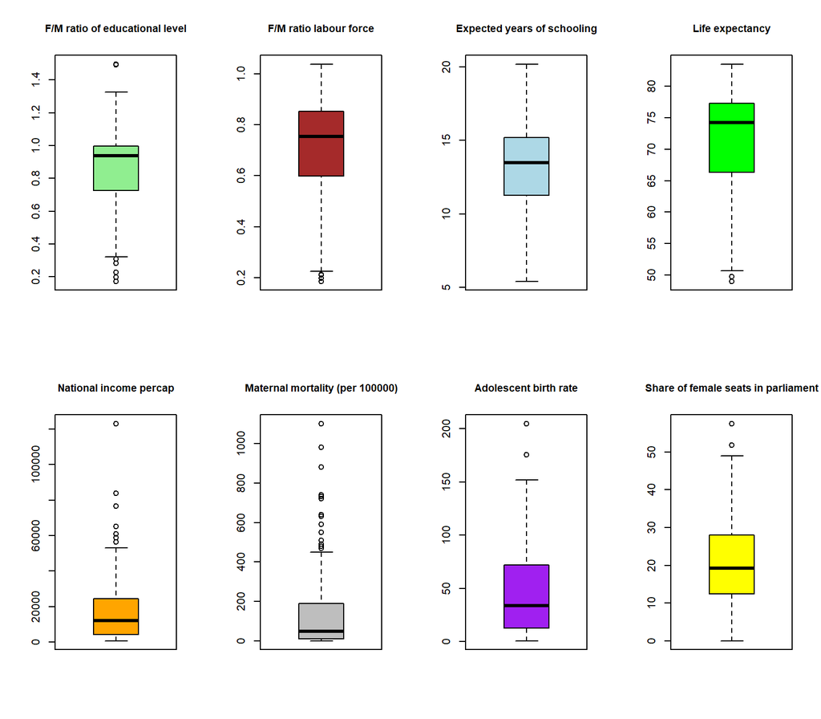

```r
par(mfrow=c(2,4))

p1<-boxplot(humanW$Edu2.FM,col="lightgreen",main="F/M ratio of educational level",cex.main=0.9, cex=1, pch=1, pt.cex =1)

p2<-boxplot(humanW$Labo.FM,col="brown",main="F/M ratio labour force",cex.main=0.9, cex=1, pch=1, pt.cex =1)

p3<-boxplot(humanW$Edu.Exp,col="lightblue",main="Expected years of schooling",cex.main=0.9, cex=1, pch=1, pt.cex =1)

p4<-boxplot(humanW$Life.Exp,col="green",main="Life expectancy",cex.main=0.9, cex=1, pch=1, pt.cex =1)

p5<-boxplot(humanW$GNI,col="orange",main="National income percap",cex.main=0.9, cex=1, pch=1, pt.cex =1)

p6<-boxplot(humanW$Mat.Mor,col="grey",main="Maternal mortality (per 100000)",cex.main=0.9, cex=1, pch=1, pt.cex =1)

p7<-boxplot(humanW$Ado.Birth,col="purple",main="Adolescent birth rate",cex.main=0.9, cex=1, pch=1, pt.cex =1)

p8<-boxplot(humanW$Parli.F,col="yellow",main="Share of female seats in parliament",cex.main=0.9, cex=1, pch=1, pt.cex =1)
```

### Data about African countries

If we now try to have a look on African countries

```r
# Africa comprises all african counties from
# https://www.countries-ofthe-world.com/countries-of-africa.html

Africa <- c("Algeria", "Angola", "Benin", "Botswana", "Burkina Faso", "Burundi", "Cabo Verde", "Cameroon", "Central African Republic (CAR)", "Chad", "Comoros", "Democratic Republic of the Congo", "Republic of the Congo", "Cote d'Ivoire", "Djibouti", "Egypt", "Equatorial Guinea", "Eritrea", "Ethiopia", "Gabon", "Gambia", "Ghana", "Guinea", "Guinea-Bissau", "Kenya", "Lesotho", "Liberia", "Libya", "Madagascar", "Malawi", "Mali", "Mauritania", "Mauritius", "Morocco", "Mozambique", "Namibia", "Niger", "Nigeria", "Rwanda", "Sao Tome and Principe", "Senegal", "Seychelles", "Sierra Leone", "Somalia", "South Africa", "South Sudan", "Sudan", "Swaziland", "Tanzania", "Togo", "Tunisia", "Uganda", "Zambia", "Zimbabwe")

# intersect Africa with row names return existing African countries

human_Africa <- humanW[intersect(Africa, row.names(humanW)),]
```

```r
reset(options)
options("scipen"=10, "digits"=2)
tab1<-CreateTableOne(vars=c( "Edu2.FM" ,"Labo.FM" ,  "Edu.Exp"   ,
"Life.Exp" ,     "GNI"  ,         "Mat.Mor"  ,    "Ado.Birth",
"Parli.F") ,data=human_Africa)
summary(tab1)
```

```
##
##      ### Summary of continuous variables ###
##
## strata: Overall
##            n miss p.miss   mean     sd median    p25    p75   min   max
## Edu2.FM   35    0      0    0.7    0.3    0.7    0.4    0.8   0.2     1
## Labo.FM   35    0      0    0.7    0.2    0.9    0.6    0.9   0.2     1
## Edu.Exp   35    0      0   10.7    2.4   10.9    8.7   12.3   5.4    16
## Life.Exp  35    0      0   61.8    6.9   61.4   57.8   64.5  49.0    75
## GNI       35    0      0 5180.2 5301.5 2762.0 1545.0 8134.0 747.0 17470
## Mat.Mor   35    0      0  381.1  247.5  360.0  205.0  485.0  15.0  1100
## Ado.Birth 35    0      0   84.6   48.1   89.4   47.5  115.8   2.5   205
## Parli.F   35    0      0   21.6   12.5   16.7   12.0   29.2   2.2    58
##             skew  kurt
## Edu2.FM    0.740  0.72
## Labo.FM   -0.827 -0.65
## Edu.Exp    0.001 -0.45
## Life.Exp   0.293 -0.19
## GNI        1.235  0.12
## Mat.Mor    0.913  1.37
## Ado.Birth  0.326 -0.09
## Parli.F    0.905  0.38
```

```r
reset(options)
```

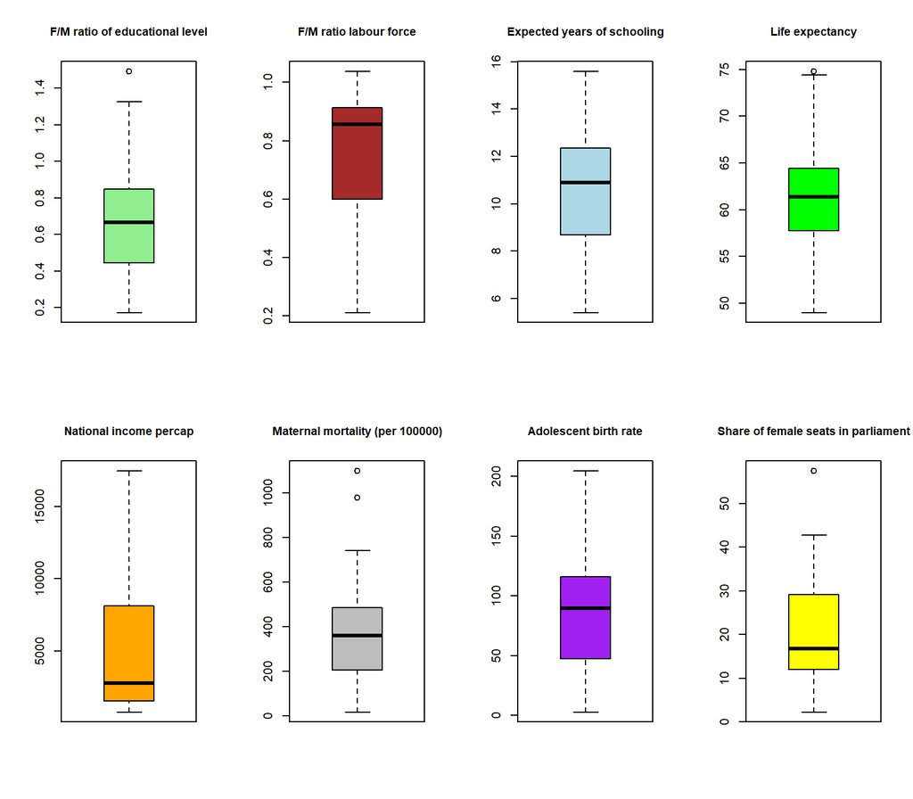

```r
par(mfrow=c(2,4))

p1<-boxplot(human_Africa$Edu2.FM,col="lightgreen",main="F/M ratio of educational level",cex.main=0.9, cex=1, pch=1, pt.cex =1)

p2<-boxplot(human_Africa$Labo.FM,col="brown",main="F/M ratio labour force",cex.main=0.9, cex=1, pch=1, pt.cex =1)

p3<-boxplot(human_Africa$Edu.Exp,col="lightblue",main="Expected years of schooling",cex.main=0.9, cex=1, pch=1, pt.cex =1)

p4<-boxplot(human_Africa$Life.Exp,col="green",main="Life expectancy",cex.main=0.9, cex=1, pch=1, pt.cex =1)

p5<-boxplot(human_Africa$GNI,col="orange",main="National income percap",cex.main=0.9, cex=1, pch=1, pt.cex =1)

p6<-boxplot(human_Africa$Mat.Mor,col="grey",main="Maternal mortality (per 100000)",cex.main=0.9, cex=1, pch=1, pt.cex =1)

p7<-boxplot(human_Africa$Ado.Birth,col="purple",main="Adolescent birth rate",cex.main=0.9, cex=1, pch=1, pt.cex =1)

p8<-boxplot(human_Africa$Parli.F,col="yellow",main="Share of female seats in parliament",cex.main=0.9, cex=1, pch=1, pt.cex =1)
```

### Plot matrices for both Whole world and African data

Here we will add a variable of being African country or not

```r
library(dplyr)
```

```r
# adding a new variable of being African or not
# compare world countries with African
row.names(humanW) %in% row.names(human_Africa)
```

```
##   [1] FALSE FALSE FALSE FALSE FALSE FALSE FALSE FALSE FALSE FALSE FALSE
##  [12] FALSE FALSE FALSE FALSE FALSE FALSE FALSE FALSE FALSE FALSE FALSE
##  [23] FALSE FALSE FALSE FALSE FALSE FALSE FALSE FALSE FALSE FALSE FALSE
##  [34] FALSE FALSE FALSE FALSE FALSE FALSE FALSE FALSE FALSE FALSE FALSE
##  [45] FALSE FALSE FALSE FALSE FALSE FALSE FALSE FALSE FALSE FALSE FALSE
##  [56] FALSE  TRUE FALSE FALSE FALSE FALSE FALSE FALSE FALSE FALSE FALSE
##  [67] FALSE FALSE FALSE FALSE FALSE FALSE FALSE  TRUE FALSE FALSE FALSE
##  [78] FALSE FALSE FALSE FALSE FALSE FALSE  TRUE  TRUE FALSE FALSE FALSE
##  [89] FALSE FALSE FALSE FALSE FALSE  TRUE FALSE  TRUE  TRUE FALSE FALSE
## [100] FALSE FALSE  TRUE FALSE FALSE FALSE FALSE FALSE FALSE  TRUE  TRUE
## [111] FALSE FALSE FALSE FALSE FALSE FALSE FALSE  TRUE  TRUE FALSE FALSE
## [122]  TRUE FALSE FALSE FALSE  TRUE FALSE  TRUE  TRUE  TRUE FALSE FALSE
## [133]  TRUE  TRUE FALSE  TRUE  TRUE  TRUE  TRUE  TRUE FALSE FALSE  TRUE
## [144]  TRUE  TRUE FALSE  TRUE  TRUE  TRUE  TRUE  TRUE  TRUE  TRUE FALSE
## [155]  TRUE
```

```r
humanW_ <- mutate(humanW, Country = row.names(humanW))

humanW_ <- mutate(humanW_, AfricanTF = row.names(humanW) %in% row.names(human_Africa))

row.names(humanW_) = humanW_$Country

humanW_ <- dplyr::select(humanW_, -Country)

# convert AfricanTF to a factor
humanW_$AfricanTF <- factor(humanW_$AfricanTF)
```

Plot matrix for world dataset

```r
library(ggplot2)
library(GGally)
```

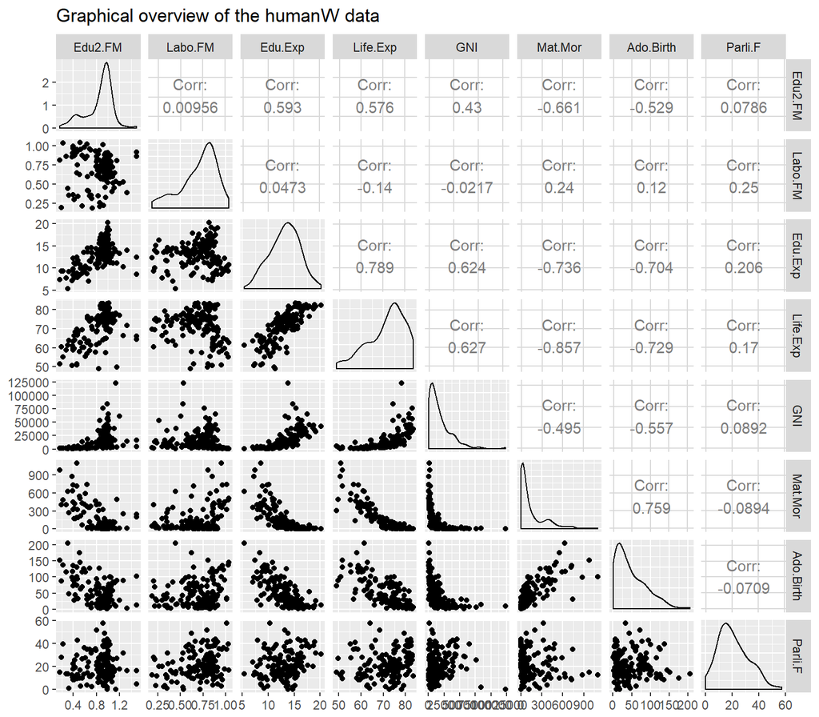

```r
#Matrix of plots for whole
pW0 <- ggpairs(humanW, lower = list(combo = wrap("facethist", bins = 20)),title="Graphical overview of the humanW data")

pW0
```

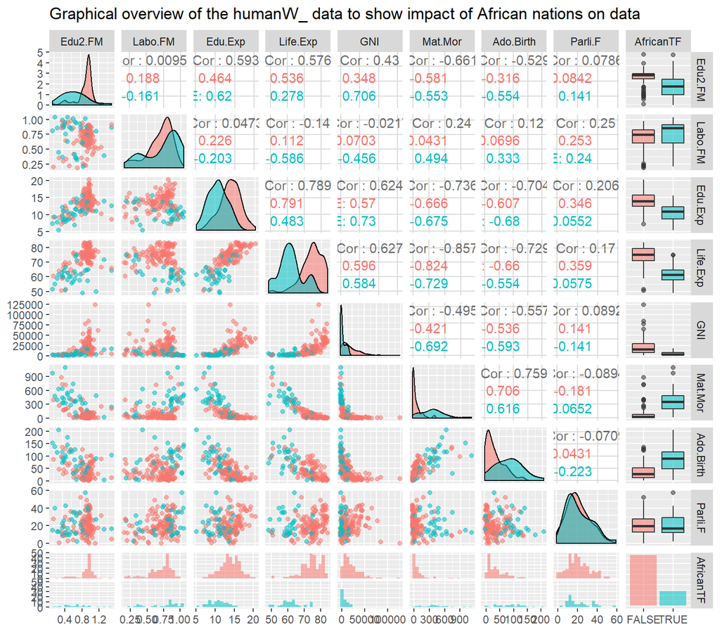

```r
#Matrix of plots
pW <- ggpairs(humanW_, mapping = aes(col = AfricanTF, alpha = 0.3), lower = list(combo = wrap("facethist", bins = 20)),title="Graphical overview of the humanW_ data to show impact of African nations on data")

pW
```

From the previous plot we can notice that African nations comprise about 23% of studied countries; nevertheless, they cause considerable heterogenity in data in almost all parameters except for the Percetange of female representatives in parliament which is surprisingly almost similar to other non-African countries.

Clear difference can be captured in African nations regarding less female to male ratio with secondary education, less expected years of schooling, less life expectance at birth, less than average GNI which is less normally distributed and higher yet more normally distributed Maternal mortality rates and Adolesence birth rates.

So, I have got the taste that in Africa the condition is *unique*.

```r
library(corrplot)
```

### Correlation matrix for African data

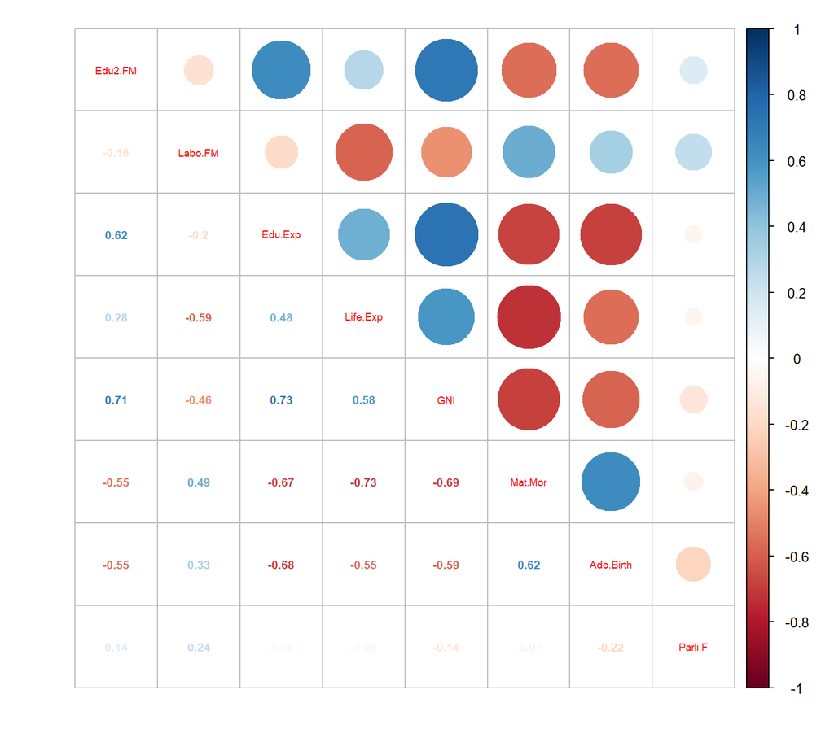

```r
#a more visual correlation matrix for African nations
cor_matrix<-cor(human_Africa) %>% round(2)
corrplot.mixed(cor_matrix,number.cex=0.65,tl.cex=0.6)
```

### What about other Non-African nations

```r
humanW_NonAf <- humanW[setdiff(row.names(humanW), Africa),]
```

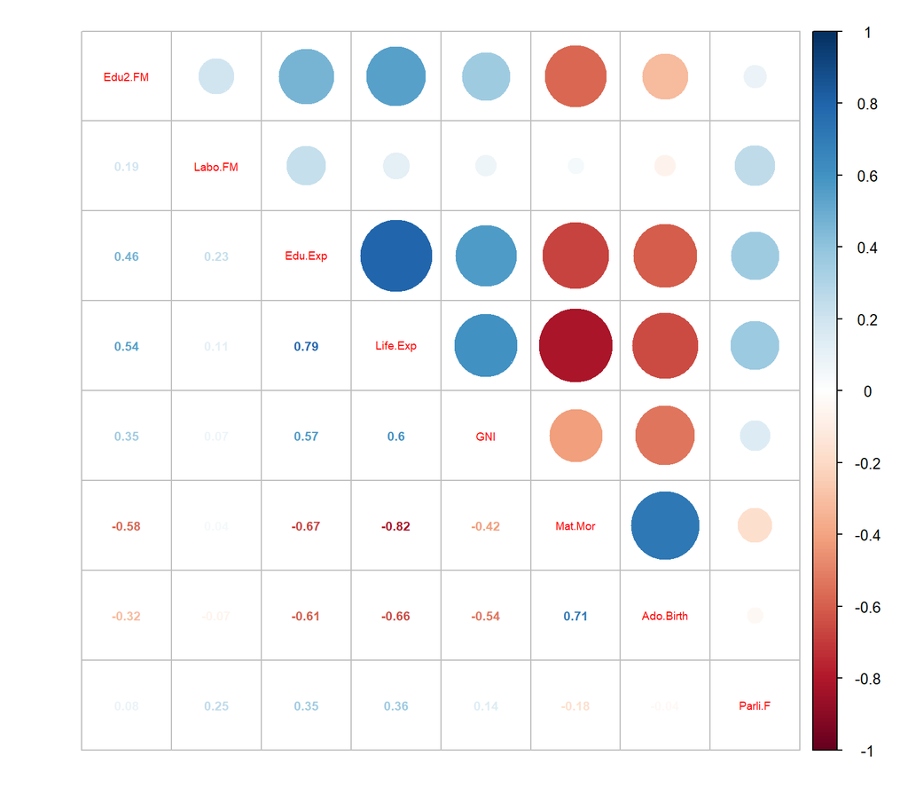

```r
#a more visual correlation matrix
cor_matrix<-cor(humanW_NonAf) %>% round(2)
corrplot.mixed(cor_matrix,number.cex=0.65,tl.cex=0.6)
```

*Now, It’s clear that GNI is differently correlated to other variables in Africa compared with non-African nations*.

## *Fitting regression model*

### for African countries

A multiple linear regression model with four explanatory variables (Edu2.FM, Labo.FM, Mat.Mor and Edu.Exp) selected based on the preliminary inspection of the dataset is fitted to investigate the relationship between them and the dependent outcome variable GNI.

```r
#First model with four explanatory variables in African
mod<-lm(GNI~Edu2.FM+Labo.FM+Mat.Mor+Edu.Exp,data=human_Africa)
summary(mod)
```

```
##
## Call:
## lm(formula = GNI ~ Edu2.FM + Labo.FM + Mat.Mor + Edu.Exp, data = human_Africa)
##
## Residuals:
##    Min     1Q Median     3Q    Max
##  -4896  -1605   -466   1603   8469
##
## Coefficients:
##             Estimate Std. Error t value Pr(>|t|)
## (Intercept) -3094.30    3931.04   -0.79   0.4374
## Edu2.FM      6688.10    2217.99    3.02   0.0052 **
## Labo.FM     -5912.74    2437.44   -2.43   0.0215 *
## Mat.Mor        -2.04       3.26   -0.63   0.5367
## Edu.Exp       840.73     315.47    2.67   0.0123 *
## ---
## Signif. codes:  0 '***' 0.001 '**' 0.01 '*' 0.05 '.' 0.1 ' ' 1
##
## Residual standard error: 2930 on 30 degrees of freedom
## Multiple R-squared:  0.731,  Adjusted R-squared:  0.695
## F-statistic: 20.3 on 4 and 30 DF,  p-value: 0.0000000342
```

The summary report of the fitted model shows that Edu2.FM has a positive impact on GNI. Interestingly, the Labo.FM has considerable negative impact on GNI and Edu.Exp has a positive impact but less than Edu2.FM, estimates for Mat.Mor prove to be non-signicifant.

Now, what if we exclude Mat.Mor from our model?

```r
# second model with three explanatory variables in African
mod2<-lm(GNI~Edu2.FM+Labo.FM+Edu.Exp,data=human_Africa)
summary(mod2)
```

```
##
## Call:
## lm(formula = GNI ~ Edu2.FM + Labo.FM + Edu.Exp, data = human_Africa)
##
## Residuals:
##    Min     1Q Median     3Q    Max
##  -5279  -1671   -349   1326   8725
##
## Coefficients:
##             Estimate Std. Error t value Pr(>|t|)
## (Intercept)    -4610       3063   -1.51   0.1424
## Edu2.FM         7025       2130    3.30   0.0025 **
## Labo.FM        -6671       2093   -3.19   0.0033 **
## Edu.Exp          942        268    3.51   0.0014 **
## ---
## Signif. codes:  0 '***' 0.001 '**' 0.01 '*' 0.05 '.' 0.1 ' ' 1
##
## Residual standard error: 2900 on 31 degrees of freedom
## Multiple R-squared:  0.727,  Adjusted R-squared:  0.701
## F-statistic: 27.5 on 3 and 31 DF,  p-value: 0.00000000711
```

in our final model the three explanatory variables are significantly affecting GNI with highest for Edu2FM.(positively) and Labo.FM(negatively), and lower with Edu.Exp(positively). Explanatory power of the final model has Adjusted R-squared of 0.701 a little bit better than the first one (0.695) indicating that the model predicts appoximately 70% of the variation in GNI.

### What about non-African countries

```r
#First model with four explanatory variables in non-African
mod_<-lm(GNI~Edu2.FM+Labo.FM+Mat.Mor+Edu.Exp,data=humanW_NonAf)
summary(mod_)
```

```
##
## Call:
## lm(formula = GNI ~ Edu2.FM + Labo.FM + Mat.Mor + Edu.Exp, data = humanW_NonAf)
##
## Residuals:
##    Min     1Q Median     3Q    Max
## -23546  -8690  -4398   5336  98435
##
## Coefficients:
##              Estimate Std. Error t value  Pr(>|t|)
## (Intercept) -41186.71   13993.98   -2.94    0.0039 **
## Edu2.FM      11823.56    9719.08    1.22    0.2263
## Labo.FM      -7797.78    8809.28   -0.89    0.3779
## Mat.Mor          1.16      16.27    0.07    0.9433
## Edu.Exp       4105.07     827.45    4.96 0.0000024 ***
## ---
## Signif. codes:  0 '***' 0.001 '**' 0.01 '*' 0.05 '.' 0.1 ' ' 1
##
## Residual standard error: 16100 on 115 degrees of freedom
## Multiple R-squared:  0.338,  Adjusted R-squared:  0.315
## F-statistic: 14.7 on 4 and 115 DF,  p-value: 0.00000000101
```

It seems that it is only Edu.Exp is significantly related to GNI, although, it explains only 31% of variations based on this model.

Now, let’s exclude nonsignificant variables from the model

```r
# second model with one explanatory variables in non-African
mod2_<-lm(GNI~Edu.Exp,data=humanW_NonAf)
summary(mod2_)
```

```
##
## Call:
## lm(formula = GNI ~ Edu.Exp, data = humanW_NonAf)
##
## Residuals:
##    Min     1Q Median     3Q    Max
## -21598  -7688  -4963   3721 102301
##
## Coefficients:
##             Estimate Std. Error t value       Pr(>|t|)
## (Intercept)   -39230       8169   -4.80 0.000004652846 ***
## Edu.Exp         4352        578    7.53 0.000000000011 ***
## ---
## Signif. codes:  0 '***' 0.001 '**' 0.01 '*' 0.05 '.' 0.1 ' ' 1
##
## Residual standard error: 16100 on 118 degrees of freedom
## Multiple R-squared:  0.324,  Adjusted R-squared:  0.319
## F-statistic: 56.6 on 1 and 118 DF,  p-value: 0.0000000000114
```

almost the same explaining about 32% of the variation in GNI based on Edu.Exp. in non-African countries.

## *Diagnostic plots*

The model fit will be explored using diagnostic plots: Residals versus Fitted values, normal QQ-plot and residuals vs Leverage.

### African countries model

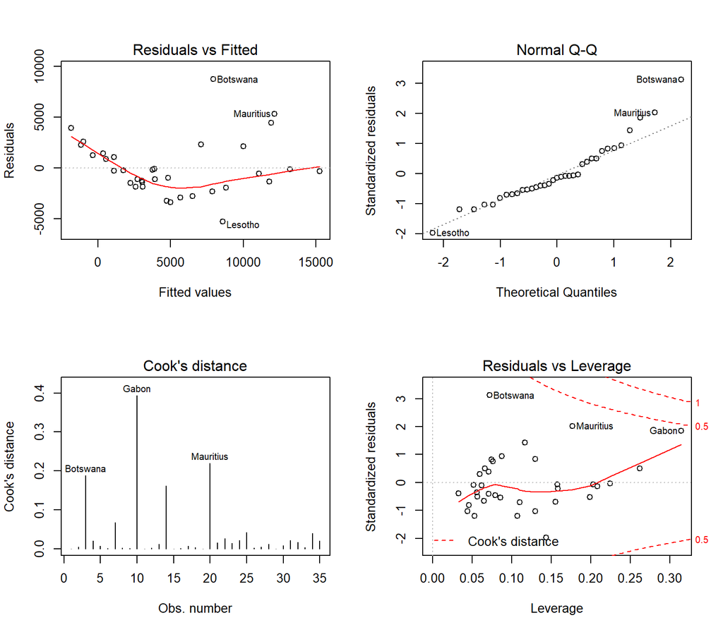

```r
#Diagnostic plots for the final model mod2

par(mfrow=c(2,2))
plot(mod2,which=c(1,2,4,5))
```

### non-African countries model

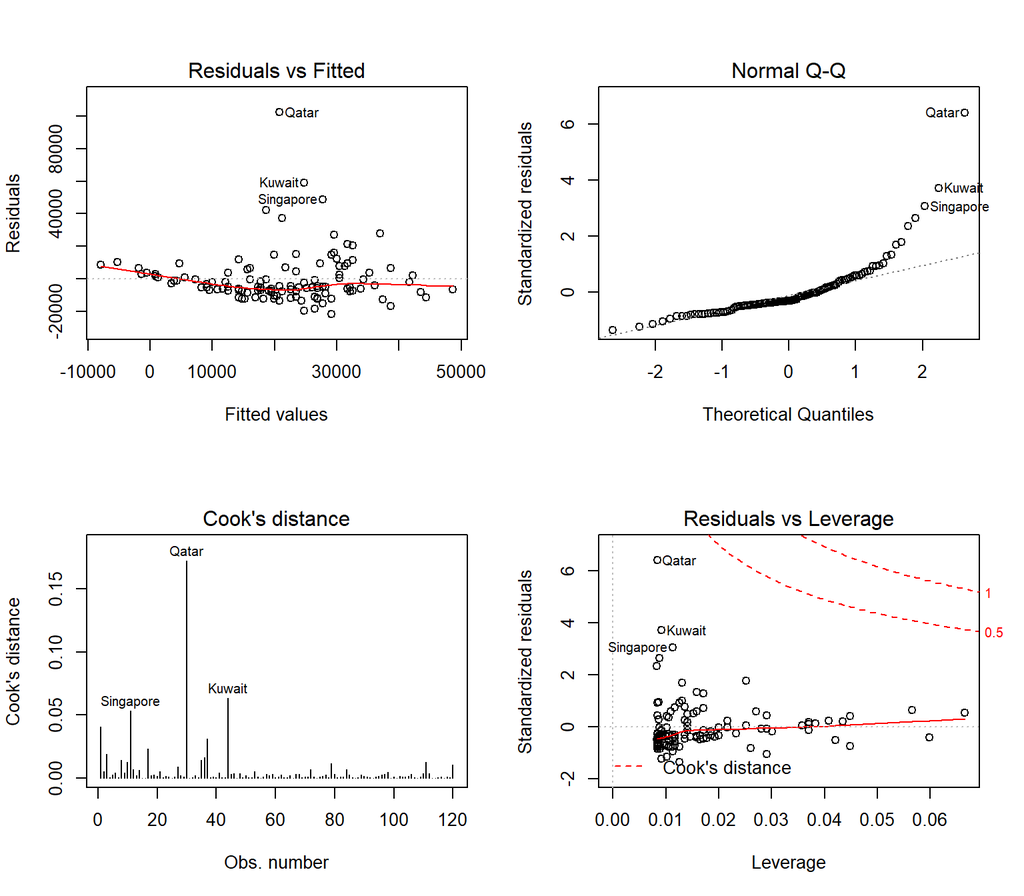

```r
#Diagnostic plots for the final model mod2_

par(mfrow=c(2,2))
plot(mod2_,which=c(1,2,4,5))
```

## *Improving model with diagnostic plots*

### African countries final model

Based on previous diagnostic plot for African countries model, try to exclude “Botswana”, “Mauritius”, “Gabon”, “Namibia”, “South Africa”

```r
# third model with three explanatory variables in African-Botswana and Mauritius
remove_these <- c("Botswana", "Mauritius", "Gabon", "Namibia", "South Africa")

rows_to_remove <- which(row.names(human_Africa) %in% remove_these)

human_Africaexc <- human_Africa[-rows_to_remove,]


mod3<-lm(GNI~Edu2.FM+Labo.FM+Edu.Exp,data=human_Africaexc)
summary(mod3)
```

```
##
## Call:
## lm(formula = GNI ~ Edu2.FM + Labo.FM + Edu.Exp, data = human_Africaexc)
##
## Residuals:
##    Min     1Q Median     3Q    Max
##  -1651   -958   -337    776   3673
##
## Coefficients:
##             Estimate Std. Error t value     Pr(>|t|)
## (Intercept)     1020       1551    0.66        0.517
## Edu2.FM         2298       1255    1.83        0.078 .
## Labo.FM        -8954       1024   -8.75 0.0000000032 ***
## Edu.Exp          764        141    5.41 0.0000112864 ***
## ---
## Signif. codes:  0 '***' 0.001 '**' 0.01 '*' 0.05 '.' 0.1 ' ' 1
##
## Residual standard error: 1370 on 26 degrees of freedom
## Multiple R-squared:  0.882,  Adjusted R-squared:  0.868
## F-statistic: 64.8 on 3 and 26 DF,  p-value: 0.00000000000337
```

Now it is Edu2.FM is less related to GNI

```r
mod4<-lm(GNI~Labo.FM+Edu.Exp,data=human_Africaexc)
summary(mod4)
```

```
##
## Call:
## lm(formula = GNI ~ Labo.FM + Edu.Exp, data = human_Africaexc)
##
## Residuals:
##    Min     1Q Median     3Q    Max
##  -1959   -826   -124    784   4644
##
## Coefficients:
##             Estimate Std. Error t value     Pr(>|t|)
## (Intercept)     1127       1616    0.70         0.49
## Labo.FM        -9301       1049   -8.87 0.0000000018 ***
## Edu.Exp          914        120    7.64 0.0000000324 ***
## ---
## Signif. codes:  0 '***' 0.001 '**' 0.01 '*' 0.05 '.' 0.1 ' ' 1
##
## Residual standard error: 1420 on 27 degrees of freedom
## Multiple R-squared:  0.867,  Adjusted R-squared:  0.857
## F-statistic: 87.9 on 2 and 27 DF,  p-value: 0.00000000000151
```

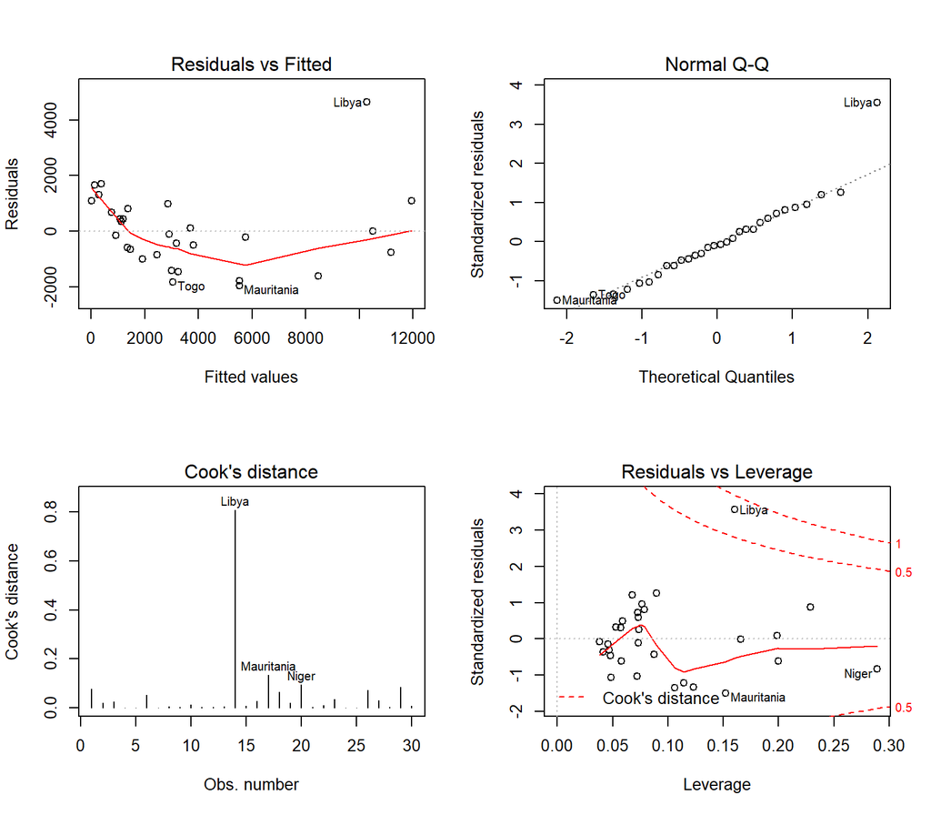

```r
#Diagnostic plots for the final model mod4

par(mfrow=c(2,2))
plot(mod4,which=c(1,2,4,5))
```

### non-African countries final model

Again, for non-African countries, exclude Quatar, Kewait, Singapore.

```r
# model with one explanatory variables in non-African
remove_these2 <- c("Qatar", "Kuwait", "Singapore")

rows_to_remove2 <- which(row.names(humanW_NonAf) %in% remove_these2)

human_nonAfricaexc <- humanW_NonAf[-rows_to_remove2,]

# model with one explanatory variables in non-African
mod3_<-lm(GNI~Edu.Exp,data=human_nonAfricaexc)
summary(mod3_)
```

```
##
## Call:
## lm(formula = GNI ~ Edu.Exp, data = human_nonAfricaexc)
##
## Residuals:
##    Min     1Q Median     3Q    Max
## -19530  -5960  -3302   4727  43932
##
## Coefficients:
##             Estimate Std. Error t value      Pr(>|t|)
## (Intercept)   -38960       5550   -7.02 0.00000000017 ***
## Edu.Exp         4203        393   10.69       < 2e-16 ***
## ---
## Signif. codes:  0 '***' 0.001 '**' 0.01 '*' 0.05 '.' 0.1 ' ' 1
##
## Residual standard error: 10900 on 115 degrees of freedom
## Multiple R-squared:  0.498,  Adjusted R-squared:  0.494
## F-statistic:  114 on 1 and 115 DF,  p-value: <2e-16
```

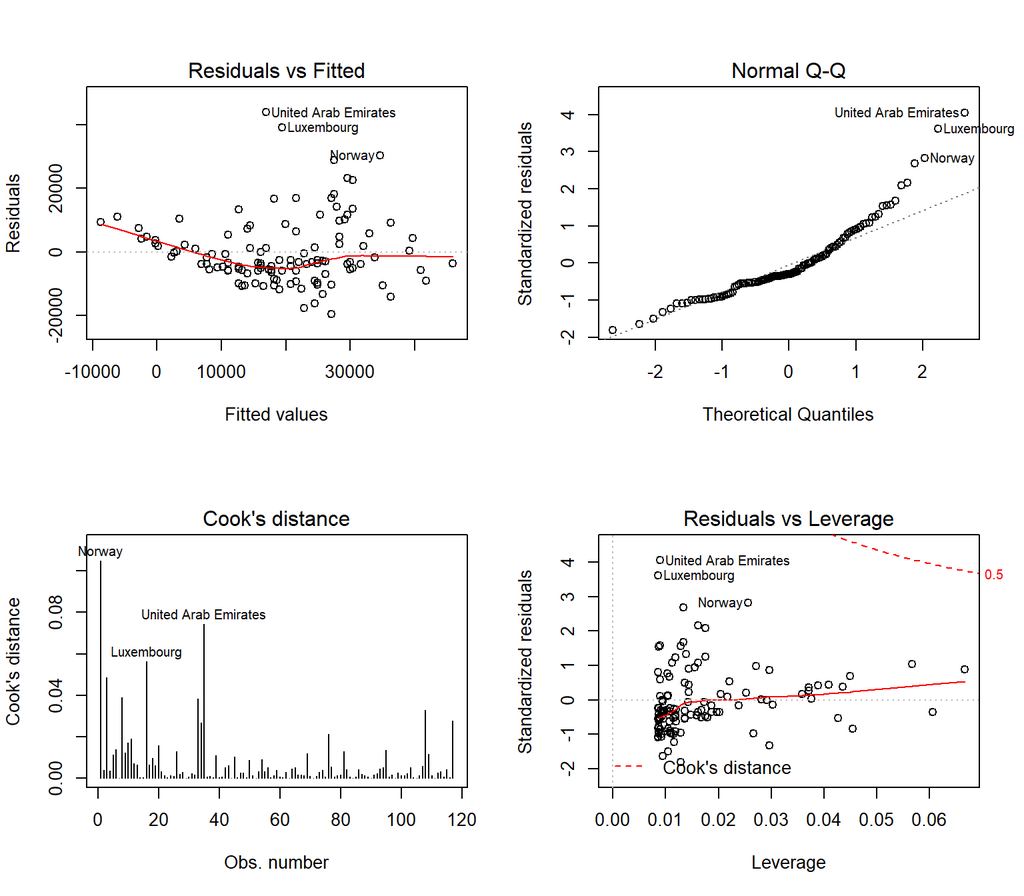

```r
#Diagnostic plots for the final model mod4

par(mfrow=c(2,2))
plot(mod3_,which=c(1,2,4,5))
```

To improve our model we excluded extreme observations that influenced our model fit. According to our improved model for non-African countries; it seems that only *Expected years of schooling* is significantly correlated positively with *GNI*, with 49% of variation explained with Edu.Exp.

## *Conclusion*

The Edu.Exp (Expected years of schooling) is a significant positive predictor for GNI in both African and non-African countries, however, ratio of females/males in the labour force is very significantly correlated as a negative predictor of GNI *only in African countries*, this means that the higher ratio of females in labour force is mostly related to lower levels of GNI.

My personal interpretation for such result could be that lower economic status is a strong drive for females’ working in African countries and not in other non-African countries, or may be that females in African countries should be addressed with development programs to improve their impact on their countries’ national income.

# Logistic Regression Analysis

Here we will review our proposed model in **African countries** to test how is it possible to predict their GNI by the level of Females ratio to males in labour force.

## *Hypothesis*

The lower ratio of females to males in the labour force, the higher GNI in African countries.

Initialy, we should make our variable of interest to be categorial for classifying and then change into numeric for further steps, let’s see how:

```r
human_Africa$GNIcat<-cut(human_Africa$GNI, c(500,1000,5000,8000,10000,18000), right=FALSE, labels=c(1:5)) %>% as.numeric()

human_Africacat <- dplyr::select(human_Africa, -GNI)

human_Africacat_ <- mutate(human_Africacat, Country = row.names(human_Africacat))

class(human_Africacat_$GNIcat)
```

```
## [1] "numeric"
```

```r
human_Africacat_ <- mutate(human_Africacat_, GNIcat2 = (human_Africacat_$GNIcat >= 3))

# showing 11 countries with more than medium GNI (TRUE), and 24 countries with lower GNI (FALSE)
summary(human_Africacat_)
```

```
##     Edu2.FM        Labo.FM        Edu.Exp        Life.Exp     Mat.Mor
##  Min.   :0.17   Min.   :0.21   Min.   : 5.4   Min.   :49   Min.   :  15
##  1st Qu.:0.44   1st Qu.:0.60   1st Qu.: 8.7   1st Qu.:58   1st Qu.: 205
##  Median :0.66   Median :0.86   Median :10.9   Median :61   Median : 360
##  Mean   :0.67   Mean   :0.75   Mean   :10.7   Mean   :62   Mean   : 381
##  3rd Qu.:0.85   3rd Qu.:0.91   3rd Qu.:12.3   3rd Qu.:64   3rd Qu.: 485
##  Max.   :1.49   Max.   :1.04   Max.   :15.6   Max.   :75   Max.   :1100
##    Ado.Birth      Parli.F       GNIcat      Country
##  Min.   :  2   Min.   : 2   Min.   :1.0   Length:35
##  1st Qu.: 48   1st Qu.:12   1st Qu.:2.0   Class :character
##  Median : 89   Median :17   Median :2.0   Mode  :character
##  Mean   : 85   Mean   :22   Mean   :2.7
##  3rd Qu.:116   3rd Qu.:29   3rd Qu.:3.5
##  Max.   :205   Max.   :58   Max.   :5.0
##   GNIcat2
##  Mode :logical
##  FALSE:24
##  TRUE :11
##
##
##
```

```r
row.names(human_Africacat_) = human_Africacat_$Country

human_Africacat_ <- dplyr::select(human_Africacat_, -Country)
```

## *Fitting the logistic regression model*

After multiple rechecking (not shown) for potential influences of other variables, Labo.FM variable seemed to be most correlated as follows

```r
#logistic regression model with explanatory variable
m1<-glm(GNIcat2~Labo.FM,data=human_Africacat_,family="binomial")
summary(m1)
```

```
##
## Call:
## glm(formula = GNIcat2 ~ Labo.FM, family = "binomial", data = human_Africacat_)
##
## Deviance Residuals:
##    Min      1Q  Median      3Q     Max
## -1.623  -0.628  -0.499   0.740   1.913
##
## Coefficients:
##             Estimate Std. Error z value Pr(>|z|)
## (Intercept)     2.87       1.35    2.13   0.0331 *
## Labo.FM        -5.14       1.84   -2.79   0.0053 **
## ---
## Signif. codes:  0 '***' 0.001 '**' 0.01 '*' 0.05 '.' 0.1 ' ' 1
##
## (Dispersion parameter for binomial family taken to be 1)
##
##     Null deviance: 43.574  on 34  degrees of freedom
## Residual deviance: 33.694  on 33  degrees of freedom
## AIC: 37.69
##
## Number of Fisher Scoring iterations: 4
```

Actually, the summary of the model confirms our hypothesis that *Ratio of females to males in the labour force* is significant (0.0053) at the 5 % level, also we notice that the direction of correlation is towrd the negative side that is to say that Labo.FM is significantly negatively correlated with GNI.

## *Odds, odds ratio and confidence intervals*

An odds ratio (OR) is a measure of association between an exposure and an outcome. The OR represents the odds that an outcome will occur given a particular exposure, compared to the odds of the outcome occurring in the absence of that exposure. See [Explaining odds Ratios](https://www.ncbi.nlm.nih.gov/pmc/articles/PMC2938757/)

When a logistic regression is calculated, the regression coefficient is the estimated increase in the log odds of the outcome per unit increase in the value of the exposure. In other words, the exponential function of the regression coefficient is the odds ratio associated with a one-unit increase in the exposure.

```r
# let's see our regression coefficient and its exponential as well as confidence intervals (CI)
coef(m1)
```

```
## (Intercept)     Labo.FM
##         2.9        -5.1
```

```r
OR <- coef(m1) %>% exp()

CI <- confint(m1) %>% exp()
```

```r
cbind(OR, CI)
```

```
##                  OR    2.5 % 97.5 %
## (Intercept) 17.6257 1.539213 358.43
## Labo.FM      0.0059 0.000098   0.16
```

## *Exploring the predictive power of our model*

```r
probabilities<-predict(m1,type="response")
predictions<-probabilities >0.5
# Add the probabilities
human_Africacat_ <- mutate(human_Africacat_, probability = probabilities)
# Calculate a logical value based on probabilites.
human_Africacat_ <- mutate(human_Africacat_, prediction = probability > 0.5)
table(high_GNI=human_Africacat_$GNIcat2,prediction=predictions) %>% addmargins %>% round(digits=2)
```

```
##         prediction
## high_GNI FALSE TRUE Sum
##    FALSE    21    3  24
##    TRUE      6    5  11
##    Sum      27    8  35
```

```r
table(high_GNI=human_Africacat_$GNIcat2,prediction=predictions) %>% prop.table %>% addmargins %>% round(digits=2)
```

```
##         prediction
## high_GNI FALSE TRUE  Sum
##    FALSE  0.60 0.09 0.69
##    TRUE   0.17 0.14 0.31
##    Sum    0.77 0.23 1.00
```

So, there were 21 true negatives, 5 true positives, 3 false positives and 6 false negatives, let’s have some graphical illustration.

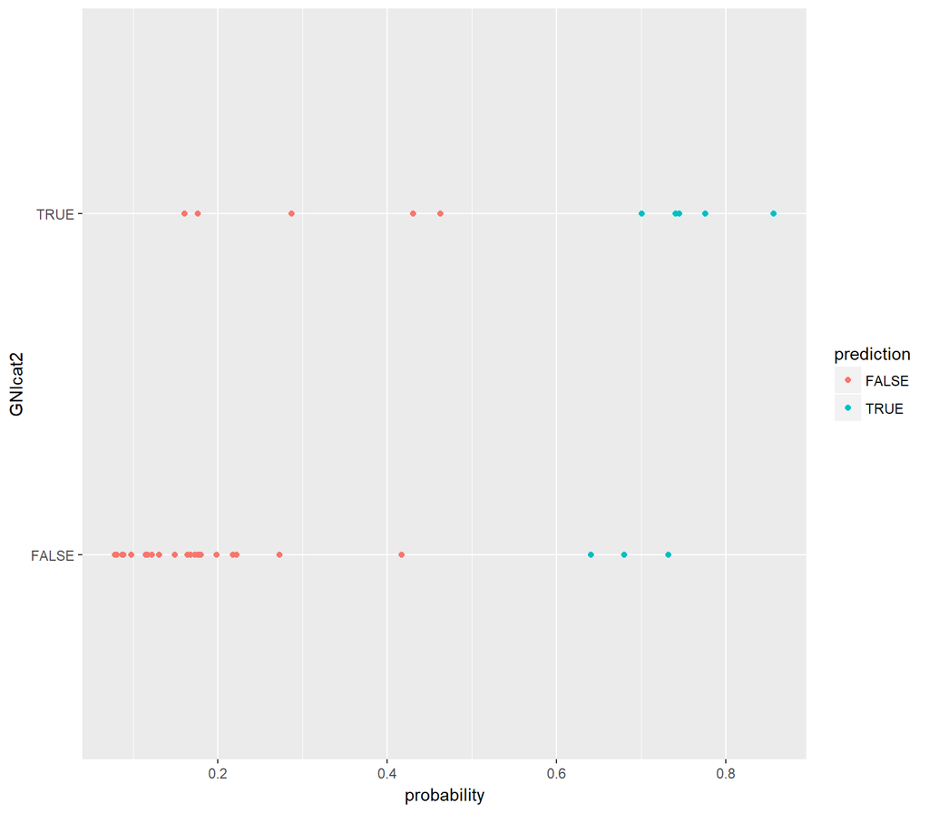

```r
g <- ggplot(human_Africacat_, aes(x = probability, y = GNIcat2, col = prediction))

g + geom_point()
```

So, we can conclude that our model is performing better in predicting less than average GNI countries in Africa based on Lab.FM data than predicting higher GNI African countries, but, how much it is bad? let’s compute the total proportion of inaccurately classified observations

```r
loss_func <- function(class, prob) {
  n_wrong <- abs(class - prob) > 0.5
  mean(n_wrong)
}

loss_func(class = human_Africacat_$GNIcat2, prob = human_Africacat_$probability)
```

```
## [1] 0.26
```

Although we have 26% of inaccurate prediction, but we still have a ggod rationale for an educated guess which is for sure would be better than random prediction.

## *Cross validation and optimization*

Cross-validation tests the model on unseen data, performing cross-validation on our model.

```r
loss_func <- function(class, prob) {
  n_wrong <- abs(class - prob) > 0.5
  mean(n_wrong)
}

loss_func(class = human_Africacat_$GNIcat2, prob = human_Africacat_$probability)
```

```
## [1] 0.26
```

```r
library(boot)
cv <- cv.glm(data = human_Africacat_, cost = loss_func, glmfit = m1, K = 10)
```

```r
cv$delta[1]
```

```
## [1] 0.26
```

Could we improve the model by including another variable? let’s check

```r
mbetter<-glm(GNIcat2~Labo.FM+Edu.Exp,family=binomial,data=human_Africacat_)

cvbetter <- cv.glm(data = human_Africacat_, cost = loss_func, glmfit = mbetter, K = 10)
```

```r
cvbetter$delta[1]
```

```
## [1] 0.11
```

## *Conclusion*

the inclusion of the variable Edu.Exp dramatically improved the model and decreased the percentage of misclassified observations significantly, I am not surprised as this goes in accordance with our initial linear regression results discussed earlier.

# Linear discriminant analysis

## *Introduction*

Linear discriminant analysis (LDA) is a generalization of Fisher’s linear discriminant, a method used in statistics, pattern recognition and machine learning to find a linear combination of features that characterizes or separates two or more classes of objects or events. The resulting combination may be used as a linear classifier, or, more commonly, for dimensionality reduction before later classification.

Here, we will continue analysind data concerning African countries with regard to their *GNI*.

## *African countries data revisited*

We will work on *African countries* data as seen next:

```r
human_AfricaLDA <- dplyr::select(human_Africa, -GNIcat)

glimpse(human_AfricaLDA)
```

```
## Observations: 35
## Variables: 8
## $ Edu2.FM   <dbl> 0.86, 0.42, 0.94, 0.28, 0.64, 0.61, 0.17, 0.72, 0.43...
## $ Labo.FM   <dbl> 0.21, 0.86, 0.88, 0.86, 1.02, 0.83, 0.81, 0.32, 0.88...
## $ Edu.Exp   <dbl> 14.0, 11.1, 12.5, 7.8, 10.1, 10.4, 7.4, 13.5, 8.5, 1...
## $ Life.Exp  <dbl> 75, 60, 64, 59, 57, 56, 52, 71, 64, 64, 60, 61, 62, ...
## $ GNI       <int> 13054, 1767, 16646, 1591, 758, 2803, 2085, 10512, 14...
## $ Mat.Mor   <int> 89, 340, 170, 400, 740, 590, 980, 45, 420, 240, 430,...
## $ Ado.Birth <dbl> 10.0, 90.2, 44.2, 115.4, 30.3, 115.8, 152.0, 43.0, 7...
## $ Parli.F   <dbl> 25.7, 8.4, 9.5, 13.3, 34.9, 27.1, 14.9, 2.2, 25.5, 1...
```

```r
summary(human_AfricaLDA)
```

```
##     Edu2.FM        Labo.FM        Edu.Exp        Life.Exp       GNI
##  Min.   :0.17   Min.   :0.21   Min.   : 5.4   Min.   :49   Min.   :  747
##  1st Qu.:0.44   1st Qu.:0.60   1st Qu.: 8.7   1st Qu.:58   1st Qu.: 1545
##  Median :0.66   Median :0.86   Median :10.9   Median :61   Median : 2762
##  Mean   :0.67   Mean   :0.75   Mean   :10.7   Mean   :62   Mean   : 5180
##  3rd Qu.:0.85   3rd Qu.:0.91   3rd Qu.:12.3   3rd Qu.:64   3rd Qu.: 8134
##  Max.   :1.49   Max.   :1.04   Max.   :15.6   Max.   :75   Max.   :17470
##     Mat.Mor       Ado.Birth      Parli.F
##  Min.   :  15   Min.   :  2   Min.   : 2
##  1st Qu.: 205   1st Qu.: 48   1st Qu.:12
##  Median : 360   Median : 89   Median :17
##  Mean   : 381   Mean   : 85   Mean   :22
##  3rd Qu.: 485   3rd Qu.:116   3rd Qu.:29
##  Max.   :1100   Max.   :205   Max.   :58
```

## *Scaling the dataset and categorising GNI*

Linear discriminant analysis is a method generating linear combinations to charachterize variable classes. To enable the method the data set should be fine-tuned by scaling the mean of every variable to zero by ubtracting the column means from the corresponding columns and dividing the difference with standard deviation.

```r
#scale the dataset
African_scaled <- as.data.frame(scale(human_AfricaLDA))

summary(African_scaled)
```

```
##     Edu2.FM         Labo.FM         Edu.Exp         Life.Exp
##  Min.   :-1.67   Min.   :-2.21   Min.   :-2.22   Min.   :-1.85
##  1st Qu.:-0.75   1st Qu.:-0.60   1st Qu.:-0.84   1st Qu.:-0.58
##  Median :-0.02   Median : 0.45   Median : 0.09   Median :-0.05
##  Mean   : 0.00   Mean   : 0.00   Mean   : 0.00   Mean   : 0.00
##  3rd Qu.: 0.60   3rd Qu.: 0.68   3rd Qu.: 0.69   3rd Qu.: 0.39
##  Max.   : 2.77   Max.   : 1.20   Max.   : 2.06   Max.   : 1.89
##       GNI           Mat.Mor        Ado.Birth        Parli.F
##  Min.   :-0.84   Min.   :-1.48   Min.   :-1.71   Min.   :-1.55
##  1st Qu.:-0.69   1st Qu.:-0.71   1st Qu.:-0.77   1st Qu.:-0.77
##  Median :-0.46   Median :-0.09   Median : 0.10   Median :-0.39
##  Mean   : 0.00   Mean   : 0.00   Mean   : 0.00   Mean   : 0.00
##  3rd Qu.: 0.56   3rd Qu.: 0.42   3rd Qu.: 0.65   3rd Qu.: 0.60
##  Max.   : 2.32   Max.   : 2.90   Max.   : 2.50   Max.   : 2.86
```

as compared with initial summary, after scaling all means adjusted to zero, what we do next is to create GNI categorial variable of scaled data, Quantiles are used for this to yield four grouping values: low, medium low, medium high and high GNI per capita and thus four groups with approximatey equal numbers of observations each, then, the data set is randomly spit for the analysis to train (80%) and test (20%) sets.

```r
# create a quantile vector of GNI, and use it to categorize GNI
bins <- quantile(African_scaled$GNI)
GNIq <- cut(African_scaled$GNI, breaks = bins, include.lowest = TRUE, label = c('low','med_low','med_high','high'))
# replace the original unscaled variable.
African_scaled <- dplyr::select(African_scaled, -GNI)
African_scaled <- data.frame(African_scaled, GNIq)
# explore the categorised variable.
summary(African_scaled)
```

```
##     Edu2.FM         Labo.FM         Edu.Exp         Life.Exp
##  Min.   :-1.67   Min.   :-2.21   Min.   :-2.22   Min.   :-1.85
##  1st Qu.:-0.75   1st Qu.:-0.60   1st Qu.:-0.84   1st Qu.:-0.58
##  Median :-0.02   Median : 0.45   Median : 0.09   Median :-0.05
##  Mean   : 0.00   Mean   : 0.00   Mean   : 0.00   Mean   : 0.00
##  3rd Qu.: 0.60   3rd Qu.: 0.68   3rd Qu.: 0.69   3rd Qu.: 0.39
##  Max.   : 2.77   Max.   : 1.20   Max.   : 2.06   Max.   : 1.89
##     Mat.Mor        Ado.Birth        Parli.F            GNIq
##  Min.   :-1.48   Min.   :-1.71   Min.   :-1.55   low     :9
##  1st Qu.:-0.71   1st Qu.:-0.77   1st Qu.:-0.77   med_low :9
##  Median :-0.09   Median : 0.10   Median :-0.39   med_high:8
##  Mean   : 0.00   Mean   : 0.00   Mean   : 0.00   high    :9
##  3rd Qu.: 0.42   3rd Qu.: 0.65   3rd Qu.: 0.60
##  Max.   : 2.90   Max.   : 2.50   Max.   : 2.86
```

as intended; now we have low, medium low, medium high and high GNI per capita in four groups with approximatey equal numbers of observations each.

Now, we need to divide the dataset to train and test sets, so that 80% of the data belongs to the train set.

```r
set.seed(123)
n <- nrow(African_scaled)
n
```

```
## [1] 35
```

```r
# choose randomly 80% of the rows
train_set <- sample(n,  size = n * 0.8)

train <- African_scaled[train_set,]

test <- African_scaled[-train_set,]

correct_classes <- test$GNIq
```

Now, let’s fit the linear discriminant analysis on the train set. Use the categorical GNIq as the target variable and all the other variables in the dataset as predictor variables.

```r
library(MASS)
```

```r
lda.fit <- lda(GNIq ~ ., data = train)

lda.fit
```

```
## Call:
## lda(GNIq ~ ., data = train)
##
## Prior probabilities of groups:
##      low  med_low med_high     high
##     0.25     0.25     0.21     0.29
##
## Group means:
##          Edu2.FM Labo.FM Edu.Exp Life.Exp Mat.Mor Ado.Birth Parli.F
## low        -0.59    0.54   -0.78    -0.20    0.57     0.374   0.449
## med_low    -0.27    0.41   -0.43    -0.41    0.50     0.443   0.142
## med_high    0.20   -0.36   -0.31    -0.68    0.11    -0.051  -0.058
## high        1.10   -0.70    1.07     0.89   -1.10    -0.946   0.062
##
## Coefficients of linear discriminants:
##              LD1   LD2    LD3
## Edu2.FM    0.690 -0.24  0.022
## Labo.FM   -0.582  0.90 -0.171
## Edu.Exp    1.239  1.04  1.427
## Life.Exp   0.322  1.86 -0.246
## Mat.Mor   -0.291  0.79  0.535
## Ado.Birth  0.270  0.97  1.124
## Parli.F   -0.082  0.30  0.035
##
## Proportion of trace:
##   LD1   LD2   LD3
## 0.810 0.179 0.011
```

Based on that we can say that percentage separations achieved by the first and second discriminant functions is about 99% which is quite fine.

## *LDA (bi)plots*

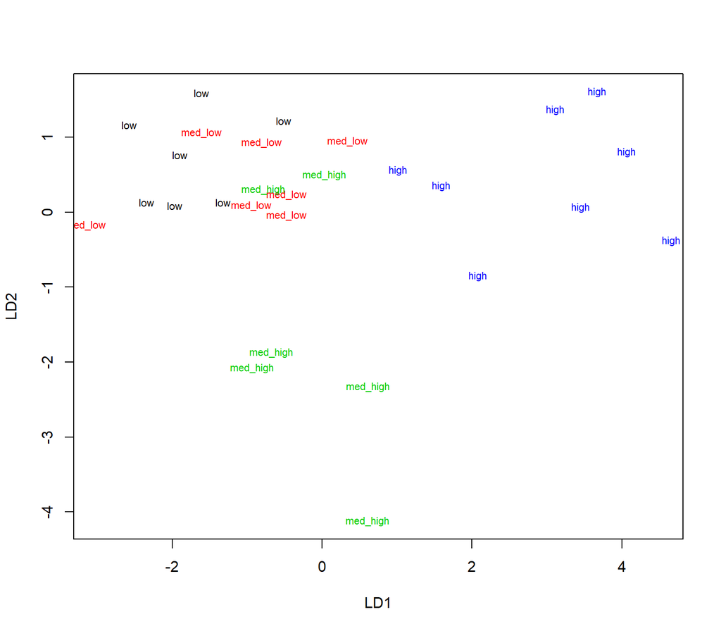

```r
# the function for lda biplot arrows
lda.arrows <- function(x, myscale = 0.8, arrow_heads = 0.08, color = "deeppink", tex = 0.95, choices = c(1,2)){
  heads <- coef(x)
  arrows(x0 = 0, y0 = 0,
         x1 = myscale * heads[,choices[1]],
         y1 = myscale * heads[,choices[2]], col=color, length = arrow_heads)
  text(myscale * heads[,choices], labels = row.names(heads),
       cex = tex, col=color, pos=3)
}

# classes as numeric
classes <- as.numeric(train$GNIq)

# plot results

p9 <- plot(lda.fit, dimen = 2, col = classes, pch = classes)
```

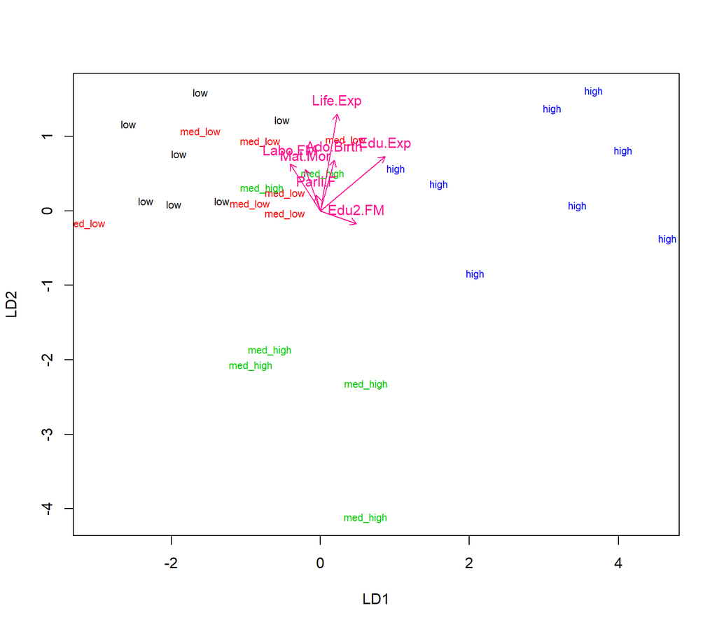

```r
#(bi)plot
p10 <- plot(lda.fit, dimen = 2, col = classes, pch = classes)
#arrows
lda.arrows(lda.fit, myscale = 0.7)
```

```r
print(lda.fit)
```

```
## Call:
## lda(GNIq ~ ., data = train)
##
## Prior probabilities of groups:
##      low  med_low med_high     high
##     0.25     0.25     0.21     0.29
##
## Group means:
##          Edu2.FM Labo.FM Edu.Exp Life.Exp Mat.Mor Ado.Birth Parli.F
## low        -0.59    0.54   -0.78    -0.20    0.57     0.374   0.449
## med_low    -0.27    0.41   -0.43    -0.41    0.50     0.443   0.142
## med_high    0.20   -0.36   -0.31    -0.68    0.11    -0.051  -0.058
## high        1.10   -0.70    1.07     0.89   -1.10    -0.946   0.062
##
## Coefficients of linear discriminants:
##              LD1   LD2    LD3
## Edu2.FM    0.690 -0.24  0.022
## Labo.FM   -0.582  0.90 -0.171
## Edu.Exp    1.239  1.04  1.427
## Life.Exp   0.322  1.86 -0.246
## Mat.Mor   -0.291  0.79  0.535
## Ado.Birth  0.270  0.97  1.124
## Parli.F   -0.082  0.30  0.035
##
## Proportion of trace:
##   LD1   LD2   LD3
## 0.810 0.179 0.011
```

Here we can see that the first two linear discriminants contribute to explain about 99% of variation in our observations and African countries are generally reasonably separated into *towards high GNI countries* with variables like *Edu.Exp* more than *Edu2.FM* contributing more to that direction and other *towards low GNI countries* with the *Labo.FM* variable contributing significantly to their classification.

## *Prediction*

Let’s test the accuracy of predictions based on our model.

```r
lda.pred <- predict(lda.fit, newdata = test)
table(correct = correct_classes, predicted = lda.pred$class) %>% addmargins()
```

```
##           predicted
## correct    low med_low med_high high Sum
##   low        0       2        0    0   2
##   med_low    2       0        0    0   2
##   med_high   0       0        0    2   2
##   high       0       0        0    1   1
##   Sum        2       2        0    3   7
```

We can capture from the crosstabulated predictions with correct that the model can effeciently classify countries into two broader classes of *(low and med_low)* and *(med_high and high)* regarding their GNI.

## *Is there better model?*

```r
lda.fit2 <- lda(GNIq ~ Labo.FM+Edu.Exp+Edu2.FM, data = train)

lda.fit2
```

```
## Call:
## lda(GNIq ~ Labo.FM + Edu.Exp + Edu2.FM, data = train)
##
## Prior probabilities of groups:
##      low  med_low med_high     high
##     0.25     0.25     0.21     0.29
##
## Group means:
##          Labo.FM Edu.Exp Edu2.FM
## low         0.54   -0.78   -0.59
## med_low     0.41   -0.43   -0.27
## med_high   -0.36   -0.31    0.20
## high       -0.70    1.07    1.10
##
## Coefficients of linear discriminants:
##           LD1   LD2   LD3
## Labo.FM -0.86 -0.70 -0.54
## Edu.Exp  1.18 -1.18  0.51
## Edu2.FM  0.73  0.75 -0.97
##
## Proportion of trace:
##    LD1    LD2    LD3
## 0.9740 0.0258 0.0002
```

LDA(bi)plots

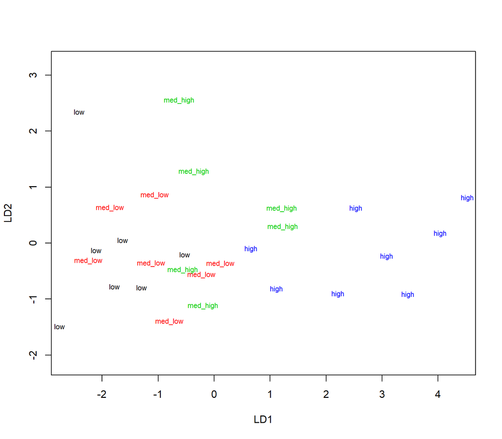

```r
# the function for lda biplot arrows
lda.arrows2 <- function(x, myscale = 0.8, arrow_heads = 0.08, color = "deeppink", tex = 0.95, choices = c(1,2)){
  heads <- coef(x)
  arrows(x0 = 0, y0 = 0,
         x1 = myscale * heads[,choices[1]],
         y1 = myscale * heads[,choices[2]], col=color, length = arrow_heads)
  text(myscale * heads[,choices], labels = row.names(heads),
       cex = tex, col=color, pos=3)
}

# classes as numeric
classes <- as.numeric(train$GNIq)

# plot results

p11 <- plot(lda.fit2, dimen = 2, col = classes, pch = classes)
```

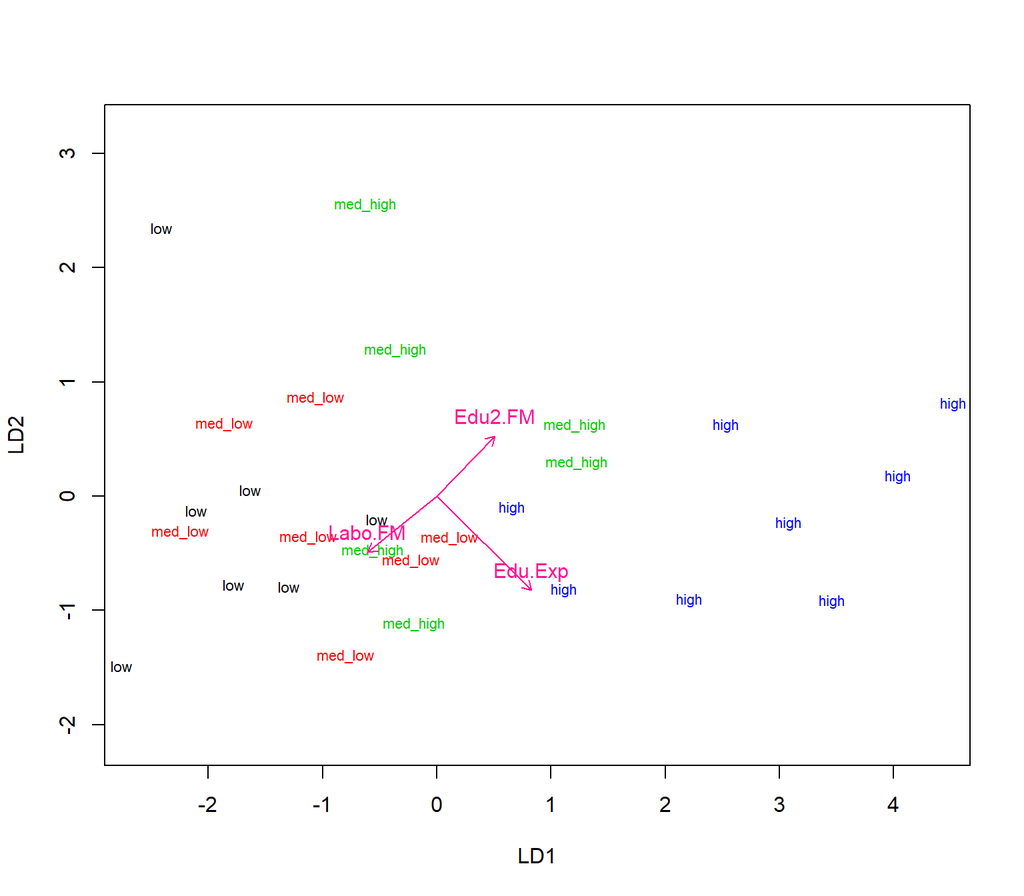

```r
#(bi)plot
p12 <- plot(lda.fit2, dimen = 2, col = classes, pch = classes)
#arrows
lda.arrows2(lda.fit2, myscale = 0.7)
```

```r
print(lda.fit2)
```

```
## Call:
## lda(GNIq ~ Labo.FM + Edu.Exp + Edu2.FM, data = train)
##
## Prior probabilities of groups:
##      low  med_low med_high     high
##     0.25     0.25     0.21     0.29
##
## Group means:
##          Labo.FM Edu.Exp Edu2.FM
## low         0.54   -0.78   -0.59
## med_low     0.41   -0.43   -0.27
## med_high   -0.36   -0.31    0.20
## high       -0.70    1.07    1.10
##
## Coefficients of linear discriminants:
##           LD1   LD2   LD3
## Labo.FM -0.86 -0.70 -0.54
## Edu.Exp  1.18 -1.18  0.51
## Edu2.FM  0.73  0.75 -0.97
##
## Proportion of trace:
##    LD1    LD2    LD3
## 0.9740 0.0258 0.0002
```

## *Re-assessing prediction bt final model*

```r
lda.pred2 <- predict(lda.fit2, newdata = test)
table(correct = correct_classes, predicted = lda.pred2$class) %>% addmargins()
```

```
##           predicted
## correct    low med_low med_high high Sum
##   low        0       2        0    0   2
##   med_low    2       0        0    0   2
##   med_high   0       0        0    2   2
##   high       0       0        0    1   1
##   Sum        2       2        0    3   7
```

Compared with previous predictions

```r
lda.pred <- predict(lda.fit, newdata = test)
table(correct = correct_classes, predicted = lda.pred$class) %>% addmargins()
```

```
##           predicted
## correct    low med_low med_high high Sum
##   low        0       2        0    0   2
##   med_low    2       0        0    0   2
##   med_high   0       0        0    2   2
##   high       0       0        0    1   1
##   Sum        2       2        0    3   7
```

## *conclusion*

Although expected to have better predictive power, the final model didn’t add to the first model and still in both we can classify countries into two broader classes of *(low and med_low)* and *(med_high and high)* regarding their GNI.

# K-means

## *Introduction*

*k-means* clustering aims to partition n observations into k clusters in which each observation belongs to the cluster with the nearest mean, serving as a prototype of the cluster. This results in a partitioning of the data space into Voronoi cells.

## *Eclidean and Manhattan distances*

We will operate on African_scaled2 data and examine the distance properties of the data and compare methods in both the Euclidian (geometric) and Manhattan (along the axes) distance.

```r
African_scaled2 <- scale(human_AfricaLDA) %>% as.data.frame()
class(African_scaled2)
```

```
## [1] "data.frame"
```

```r
#Euclidean distance matrix
dist_eu<-dist(African_scaled2)
#for comparison Manhattan distance matrix
dist_man<-dist(African_scaled2,method = "manhattan" )
#summaries
summary(dist_eu)#Euclidian
```

```
##    Min. 1st Qu.  Median    Mean 3rd Qu.    Max.
##     1.1     2.7     3.6     3.7     4.7     8.0
```

```r
summary(dist_man)#Manhattan
```

```
##    Min. 1st Qu.  Median    Mean 3rd Qu.    Max.
##     2.1     6.0     8.3     8.9    11.3    20.8
```

## *Preliminary K-means and determination of the optimal number of clusters*

K-means algorith is exploratorily ran on the dataset using 5 clusters.

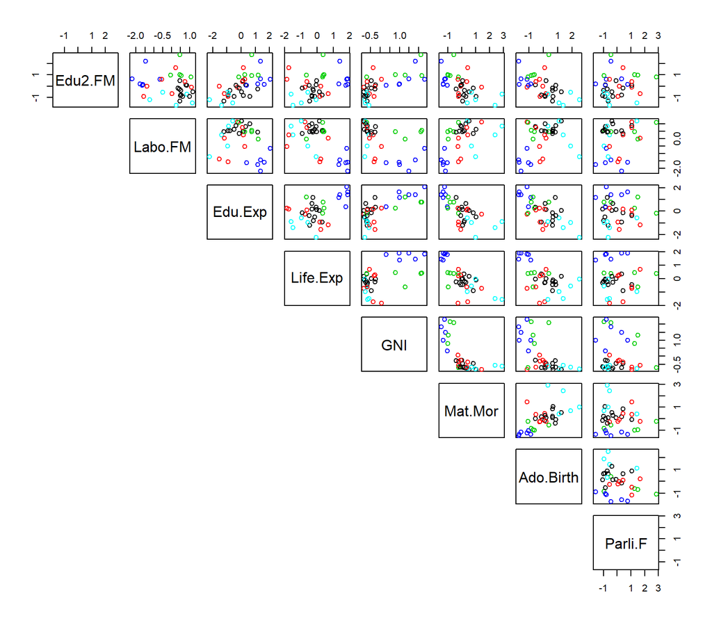

```r
#kmeans using euclidean and five clusters
km <- kmeans(dist_eu, centers = 5)
pairs(African_scaled2, col = km$cluster,lower.panel = NULL)
```

Now, let’s assess what is the optimal number of clusters and run the algorithm again.

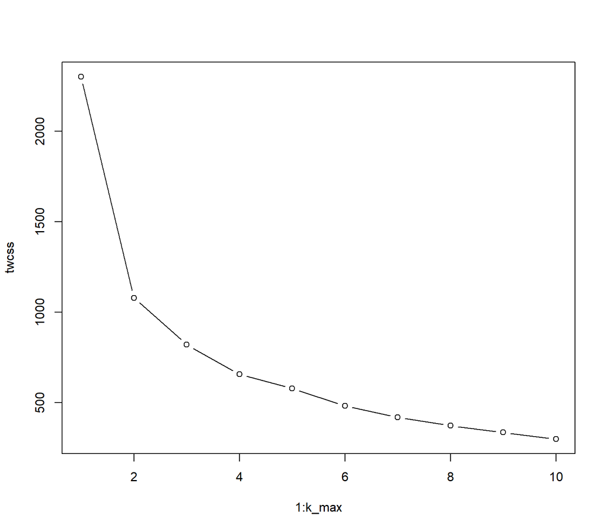

```r
k_max <- 10
twcss <- sapply(1:k_max, function(k){kmeans(dist_eu, k)$tot.withinss})
#Plot the results
plot(1:k_max, twcss, type = 'b')
```

So, the plot shows that optimally we would have 2 clusters as the most prominent change in the sum of squares happens at 2.

## *K-means using the optimal number of clusters*

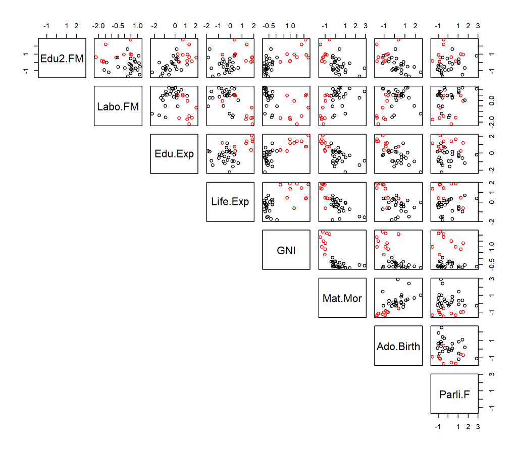

```r
km <- kmeans(dist_eu, centers = 2)
pairs(African_scaled2, col = km$cluster, lower.panel = NULL)
```

The scatter plot with only two clusters shows all data points are assigned to two red/black clusters. The clearer separation for the colours the more relevant for clustering the variable. GNI and Labo.FM seem to discriminate quite well between the two clusters.

## *LDA fitting to K-means*

This will be performed by K-means on the scaled data using 4 clusters. Therafter, LDA is fitted using the generated clusters as target classes.

```r
set.seed(123)

African_scaled4 <- as.data.frame(scale(human_AfricaLDA,center=TRUE,scale = TRUE))
dist_eu4 <- dist(African_scaled4)
km2 <-kmeans(dist_eu4, centers = 4)
```

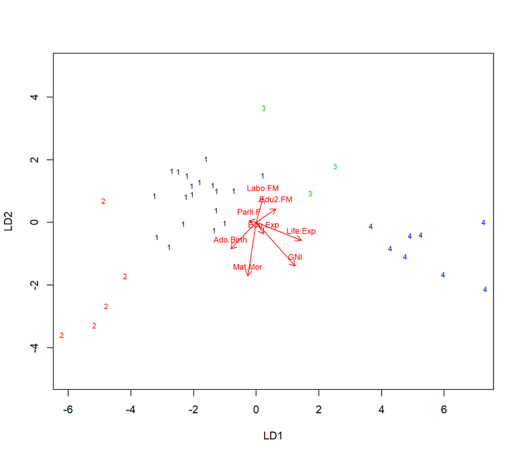

```r
African_scaled4$classes<-km2$cluster
lda.fit3 <- lda(African_scaled4$classes ~., data = African_scaled4)
lda.arrows3 <- function(x, myscale = 1, arrow_heads = 0.1, color = "red", tex = 0.75, choices = c(1,2)){
  heads <- coef(x)
  arrows(x0 = 0, y0 = 0,
         x1 = myscale * heads[,choices[1]],
         y1 = myscale * heads[,choices[2]], col=color, length = arrow_heads)
  text(myscale * heads[,choices], labels = row.names(heads),
       cex = tex, col=color, pos=3)
}
plot(lda.fit3, dimen = 2, col= as.numeric(African_scaled4$classes), pch=classes)
lda.arrows3(lda.fit3, myscale = 1)
```

Again, four clusters separated and we can taste the opposite dirction of GNI with Labo.FM in African countries.

# Appendix

## *Linear Discrimination Analysis for Non-African countries*

We will work on *Non-African countries* data as seen next:

```r
human_nonAfricaLDA <- humanW_NonAf

summary(human_nonAfricaLDA)
```

```
##     Edu2.FM        Labo.FM        Edu.Exp        Life.Exp
##  Min.   :0.20   Min.   :0.19   Min.   : 7.2   Min.   :51
##  1st Qu.:0.86   1st Qu.:0.60   1st Qu.:12.4   1st Qu.:71
##  Median :0.97   Median :0.75   Median :13.9   Median :75
##  Mean   :0.91   Mean   :0.70   Mean   :13.9   Mean   :75
##  3rd Qu.:1.00   3rd Qu.:0.82   3rd Qu.:15.7   3rd Qu.:79
##  Max.   :1.50   Max.   :0.98   Max.   :20.2   Max.   :84
##       GNI            Mat.Mor      Ado.Birth      Parli.F
##  Min.   :   581   Min.   :  1   Min.   :  1   Min.   : 0
##  1st Qu.:  7337   1st Qu.:  8   1st Qu.: 12   1st Qu.:12
##  Median : 15606   Median : 28   Median : 27   Median :20
##  Mean   : 21258   Mean   : 81   Mean   : 36   Mean   :21
##  3rd Qu.: 29144   3rd Qu.: 86   3rd Qu.: 52   3rd Qu.:28
##  Max.   :123124   Max.   :880   Max.   :135   Max.   :52
```

## *Scaling the dataset and categorising GNI*

Linear discriminant analysis is a method generating linear combinations to charachterize variable classes. To enable the method the data set should be fine-tuned by scaling the mean of every variable to zero by ubtracting the column means from the corresponding columns and dividing the difference with standard deviation.

```r
#scale the dataset
Non_African_scaled <- as.data.frame(scale(human_nonAfricaLDA))

summary(Non_African_scaled)
```

```
##     Edu2.FM        Labo.FM         Edu.Exp         Life.Exp
##  Min.   :-3.7   Min.   :-2.78   Min.   :-2.63   Min.   :-3.8
##  1st Qu.:-0.2   1st Qu.:-0.53   1st Qu.:-0.60   1st Qu.:-0.6
##  Median : 0.3   Median : 0.28   Median : 0.00   Median : 0.1
##  Mean   : 0.0   Mean   : 0.00   Mean   : 0.00   Mean   : 0.0
##  3rd Qu.: 0.5   3rd Qu.: 0.68   3rd Qu.: 0.71   3rd Qu.: 0.8
##  Max.   : 3.1   Max.   : 1.53   Max.   : 2.48   Max.   : 1.4
##       GNI          Mat.Mor       Ado.Birth        Parli.F
##  Min.   :-1.1   Min.   :-0.6   Min.   :-1.13   Min.   :-1.85
##  1st Qu.:-0.7   1st Qu.:-0.5   1st Qu.:-0.77   1st Qu.:-0.73
##  Median :-0.3   Median :-0.4   Median :-0.28   Median :-0.11
##  Mean   : 0.0   Mean   : 0.0   Mean   : 0.00   Mean   : 0.00
##  3rd Qu.: 0.4   3rd Qu.: 0.0   3rd Qu.: 0.49   3rd Qu.: 0.64
##  Max.   : 5.2   Max.   : 5.6   Max.   : 3.14   Max.   : 2.77
```

as compared with initial summary, after scaling all means adjusted to zero, what we do next is to create GNI categorial variable of scaled data, Quantiles are used for this to yield four grouping values: low, medium low, medium high and high GNI per capita and thus four groups with approximatey equal numbers of observations each, then, the data set is randomly spit for the analysis to train (80%) and test (20%) sets.

```r
# create a quantile vector of GNI, and use it to categorize GNI
bins2 <- quantile(Non_African_scaled$GNI)
GNIq2 <- cut(Non_African_scaled$GNI, breaks = bins2, include.lowest = TRUE, label = c('low','med_low','med_high','high'))
# replace the original unscaled variable.
Non_African_scaled <- dplyr::select(Non_African_scaled, -GNI)
Non_African_scaled <- data.frame(Non_African_scaled, GNIq2)
# explore the categorised variable.
summary(Non_African_scaled)
```

```
##     Edu2.FM        Labo.FM         Edu.Exp         Life.Exp
##  Min.   :-3.7   Min.   :-2.78   Min.   :-2.63   Min.   :-3.8
##  1st Qu.:-0.2   1st Qu.:-0.53   1st Qu.:-0.60   1st Qu.:-0.6
##  Median : 0.3   Median : 0.28   Median : 0.00   Median : 0.1
##  Mean   : 0.0   Mean   : 0.00   Mean   : 0.00   Mean   : 0.0
##  3rd Qu.: 0.5   3rd Qu.: 0.68   3rd Qu.: 0.71   3rd Qu.: 0.8
##  Max.   : 3.1   Max.   : 1.53   Max.   : 2.48   Max.   : 1.4
##     Mat.Mor       Ado.Birth        Parli.F           GNIq2
##  Min.   :-0.6   Min.   :-1.13   Min.   :-1.85   low     :30
##  1st Qu.:-0.5   1st Qu.:-0.77   1st Qu.:-0.73   med_low :30
##  Median :-0.4   Median :-0.28   Median :-0.11   med_high:30
##  Mean   : 0.0   Mean   : 0.00   Mean   : 0.00   high    :30
##  3rd Qu.: 0.0   3rd Qu.: 0.49   3rd Qu.: 0.64
##  Max.   : 5.6   Max.   : 3.14   Max.   : 2.77
```

as intended; now we have low, medium low, medium high and high GNI per capita in four groups with approximatey equal numbers of observations each.

Now, we need to divide the dataset to train and test sets, so that 80% of the data belongs to the train set.

```r
set.seed(123)
n2 <- nrow(Non_African_scaled)
n2
```

```
## [1] 120
```

```r
# choose randomly 80% of the rows
train_set2 <- sample(n2,  size = n2 * 0.8)

train2 <- Non_African_scaled[train_set2,]

test2 <- Non_African_scaled[-train_set2,]

correct_classes2 <- test2$GNIq2
```

Now, let’s fit the linear discriminant analysis on the train set. Use the categorical GNIq2 as the target variable and all the other variables in the dataset as predictor variables.

```r
library(MASS)
```

```r
lda.fit_nonAf <- lda(GNIq2 ~ ., data = train2)

lda.fit_nonAf
```

```
## Call:
## lda(GNIq2 ~ ., data = train2)
##
## Prior probabilities of groups:
##      low  med_low med_high     high
##     0.24     0.24     0.27     0.25
##
## Group means:
##          Edu2.FM Labo.FM Edu.Exp Life.Exp Mat.Mor Ado.Birth Parli.F
## low       -0.418  -0.041   -1.08    -0.85    0.72      0.64  -0.246
## med_low    0.019  -0.346   -0.18    -0.13   -0.16      0.29  -0.086
## med_high   0.274   0.018    0.29     0.22   -0.35     -0.21  -0.168
## high       0.385   0.135    0.85     0.96   -0.51     -0.85   0.505
##
## Coefficients of linear discriminants:
##              LD1    LD2   LD3
## Edu2.FM    0.188  0.098 -0.25
## Labo.FM   -0.144 -0.069 -0.70
## Edu.Exp    0.828 -0.860 -0.43
## Life.Exp   1.075  1.044  0.29
## Mat.Mor    0.855  1.790 -0.37
## Ado.Birth -0.732 -0.962  0.18
## Parli.F    0.055  0.439  0.77
##
## Proportion of trace:
##   LD1   LD2   LD3
## 0.861 0.123 0.016
```

Based on that we can say that percentage separations achieved by the first and second discriminant functions is about 99% which is quite fine.

## *LDA (bi)plots*

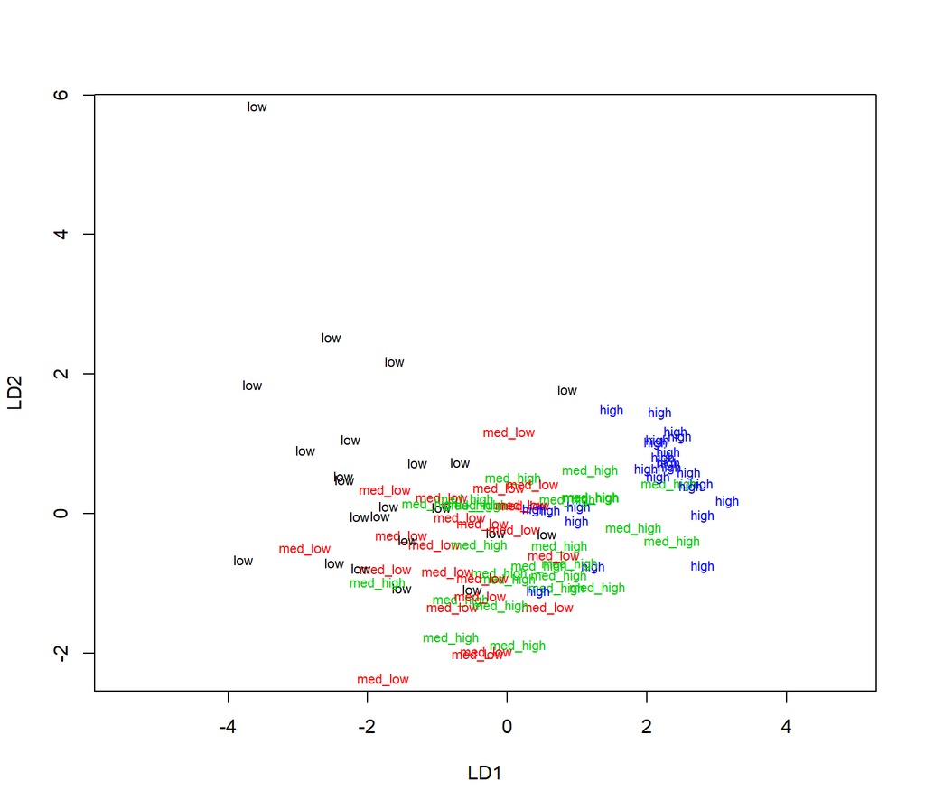

```r
# the function for lda biplot arrows
lda.arrows4 <- function(x, myscale = 2, arrow_heads = 0.2, color = "deeppink", tex = 1, choices = c(1,2)){
  heads <- coef(x)
  arrows(x0 = 0, y0 = 0,
         x1 = myscale * heads[,choices[1]],
         y1 = myscale * heads[,choices[2]], col=color, length = arrow_heads)
  text(myscale * heads[,choices], labels = row.names(heads),
       cex = tex, col=color, pos=3)
}

# classes as numeric
classes <- as.numeric(train2$GNIq2)

# plot results

p13 <- plot(lda.fit_nonAf, dimen = 2, col = classes, pch = classes)
```

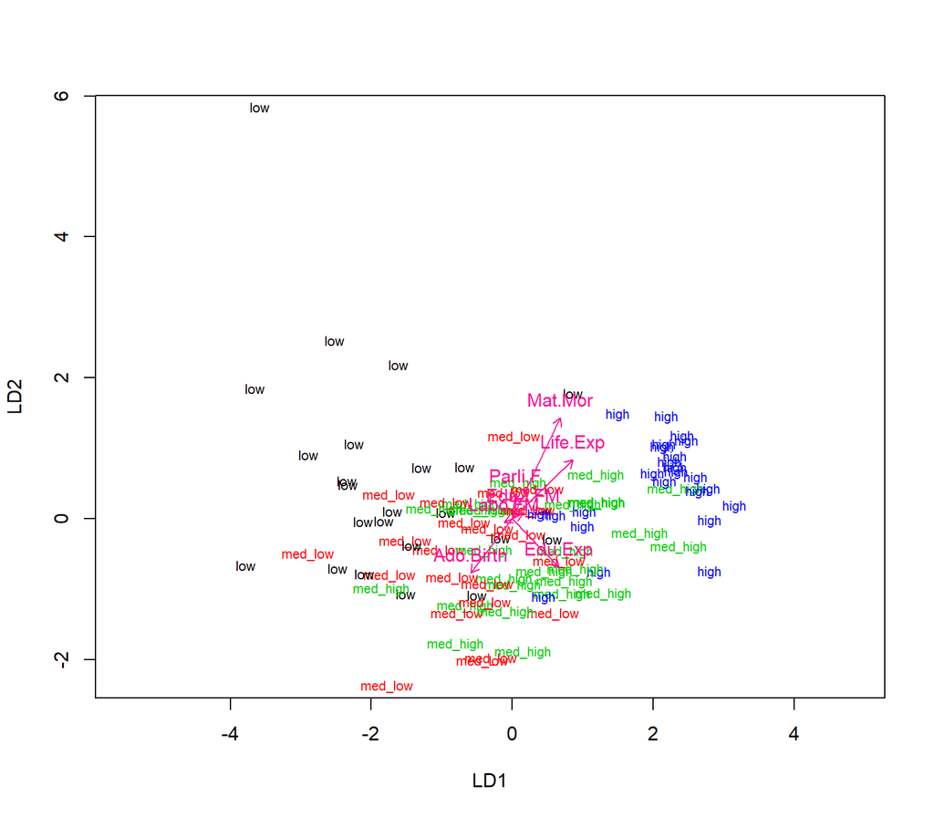

```r
#(bi)plot
p14 <- plot(lda.fit_nonAf, dimen = 2, col = classes, pch = classes)
#arrows
lda.arrows(lda.fit_nonAf)
```

```r
print(lda.fit_nonAf)
```

```
## Call:
## lda(GNIq2 ~ ., data = train2)
##
## Prior probabilities of groups:
##      low  med_low med_high     high
##     0.24     0.24     0.27     0.25
##
## Group means:
##          Edu2.FM Labo.FM Edu.Exp Life.Exp Mat.Mor Ado.Birth Parli.F
## low       -0.418  -0.041   -1.08    -0.85    0.72      0.64  -0.246
## med_low    0.019  -0.346   -0.18    -0.13   -0.16      0.29  -0.086
## med_high   0.274   0.018    0.29     0.22   -0.35     -0.21  -0.168
## high       0.385   0.135    0.85     0.96   -0.51     -0.85   0.505
##
## Coefficients of linear discriminants:
##              LD1    LD2   LD3
## Edu2.FM    0.188  0.098 -0.25
## Labo.FM   -0.144 -0.069 -0.70
## Edu.Exp    0.828 -0.860 -0.43
## Life.Exp   1.075  1.044  0.29
## Mat.Mor    0.855  1.790 -0.37
## Ado.Birth -0.732 -0.962  0.18
## Parli.F    0.055  0.439  0.77
##
## Proportion of trace:
##   LD1   LD2   LD3
## 0.861 0.123 0.016
```

We notice here that life.Exp, Edu.Exp, Mat.Mor and (negatively) Ado.Birth are the major discriminants for about 86% of variations in observations in non-African countries.

## *Prediction*

Let’s test the accuracy of predictions based on our model.

```r
lda.pred_nonAfr <- predict(lda.fit_nonAf, newdata = test2)
table(correct = correct_classes2, predicted = lda.pred_nonAfr$class) %>% addmargins()
```

```
##           predicted
## correct    low med_low med_high high Sum
##   low        7       0        0    0   7
##   med_low    0       2        5    0   7
##   med_high   0       0        3    1   4
##   high       0       0        1    5   6
##   Sum        7       2        9    6  24
```

## *Conclusion*

This model prediction is good for *low* and *high* GNI categories based on the variables of life.Exp, Edu.Exp, Mat.Mor and (negatively) Ado.Birth as the major discriminants, however, for med_low and med_high it’s not as accurate.

# Summary

There is clear difference in the correlation and impact of variables between African countries and non-African countries. Such difference should be assessed as well among different continents, and it throughs the light on different cultural and social factors that confounds with observations and that should be approached with care before drawing any generalized conclusions based on heterogenous backgrounds. Taking into consideration those differences yet increases our understanding of human behavior in communities around the world; allowing us improve and enhance human development.